# Repaso de Reducción de dimensiones

El objetivo es que entendamos de una manera visual, que es lo que pasa cuando nosotros seleccionamos cierto número de componentes principales o % de variabilidad de una base de datos.

Primero entenderemos, que pasa adentro de PCA que se basa en lo siguiente a grandes razgos:

**Análisis de Componentes Principales**

El análisis de datos multivariados involucra determinar transformaciones lineales que ayuden a entender las relaciones entre las características importantes de los datos. La idea central del Análisis de Componentes Principales (PCA) es reducir las dimensiones de un conjunto de datos que presenta variaciones correlacionadas, reteniendo una buena proporción de la variación presente en dicho conjunto. Esto se logra obteniendo la transformación a un nuevo conjunto de variables: los componentes principales (PC). Cada PC es una combinación lineal con máxima varianza en dirección ortogonal a los demás PC.

[figure not shown]

Para entender un poco más de PCA y SVD, visita el siguiente link: *Truco: Prueba entrar con tu cuenta del tec :)*

https://towardsdatascience.com/pca-and-svd-explained-with-numpy-5d13b0d2a4d8

Basicamente, vamos a seguir los siguientes pasos:

1. Obtener la covarianza. OJO: X tiene sus datos centrados :)

[figure not shown]

1. Los componentes principales se van a obtener de la eigen descomposicion de la matriz de covarianza.

[figure not shown]

1. Para la reducción de dimensiones vamos a seleccionar k vectores de W y proyectaremos nuestros datos.

[figure not shown]

# Ejercicio 1, Descomposición y composición

*Descomposición*

Encuentra los eigenvalores y eigenvectores de las siguientes matrices

$A = \begin{pmatrix} 3,0,2 \\ 3,0,-2 \\ 0,1,1 \end{pmatrix}$ $A2 = \begin{pmatrix} 1,3,8 \\ 2,0,0 \\ 0,0,1 \end{pmatrix}$ $A3 = \begin{pmatrix} 5,4,0 \\ 1,0,1 \\ 10,7,1 \end{pmatrix}$

y reconstruye la matriz original a traves de las matrices $WDW^{-1}$ (OJO. Esto es lo mismo de la ecuación del paso 2 solo le cambiamos la variable a la matriz diagonal)

# Eigenvalores y eigenvectores

```python
###-----------------EJEMPLO DE EIGENVALORES
from pprint import pprint
import numpy as np
from numpy import array
from numpy.linalg import eig
# define la matriz
A = array([[1, 2, 3], [4, 5, 6], [7, 8, 9]])
print("-------Matriz original-------")
print(A)
print("-----------------------------")
# calcula la eigendescomposición
values, vectors = eig(A)
print(values) #D
print(vectors) #W

#Ejemplo de reconstrucción


values, vectors = np.linalg.eig(A)

W = vectors
Winv = np.linalg.inv(W)
D = np.diag(values)
#la matriz B tiene que dar igual a A
#reconstruye la matriz
print("-------Matriz reconstruida-------")
# Realiza la reconstruccion de B=W*D*Winv, te da lo mismo de A?
#ojo, estas multiplicando matrices, no escalares ;)
#TU CODIGO AQUI-------------------------------------
WD = np.matmul(W, D)
B = np.matmul(WD, Winv)
print(B)
print("-----------------------------")
```

```
-------Matriz original-------
[[1 2 3]
 [4 5 6]
 [7 8 9]]
-----------------------------
[ 1.61168440e+01 -1.11684397e+00 -1.30367773e-15]
[[-0.23197069 -0.78583024  0.40824829]
 [-0.52532209 -0.08675134 -0.81649658]
 [-0.8186735   0.61232756  0.40824829]]
-------Matriz reconstruida-------
[[1. 2. 3.]
 [4. 5. 6.]
 [7. 8. 9.]]
-----------------------------
```

```python
A = array([[3, 0, 2], [3, 0, -2], [0, 1, 1]])
values, vectors = eig(A)
print(values) #D
print(vectors) #W
```

```
[3.54451153+0.j         0.22774424+1.82582815j 0.22774424-1.82582815j]
[[-0.80217543+0.j         -0.04746658+0.2575443j  -0.04746658-0.2575443j ]
 [-0.55571339+0.j          0.86167879+0.j          0.86167879-0.j        ]
 [-0.21839689+0.j         -0.16932106-0.40032224j -0.16932106+0.40032224j]]
```

```python
#Matriz 1
A = array([[3, 0, 2], [3, 0, -2], [0, 1, 1]])
print("Matriz original: \n", A)
# calcula la eigendescomposición
values, vectors = eig(A)
print("Valores: \n", values) #D
print("Vectores: \n", vectors) #W

# Reconstruccion
values, vectors = np.linalg.eig(A)

W = vectors
Winv = np.linalg.inv(W)
D = np.diag(values)

WD = np.matmul(W, D)
B = np.matmul(WD, Winv)
print("Matriz reconstruida: \n", B)
```

```
Matriz original:
 [[ 3  0  2]
 [ 3  0 -2]
 [ 0  1  1]]
Valores:
 [3.54451153+0.j         0.22774424+1.82582815j 0.22774424-1.82582815j]
Vectores:
 [[-0.80217543+0.j         -0.04746658+0.2575443j  -0.04746658-0.2575443j ]
 [-0.55571339+0.j          0.86167879+0.j          0.86167879-0.j        ]
 [-0.21839689+0.j         -0.16932106-0.40032224j -0.16932106+0.40032224j]]
Matriz reconstruida:
 [[ 3.00000000e+00-1.90344153e-18j  3.90312782e-16+2.44274141e-18j
   2.00000000e+00+1.20428621e-17j]
 [ 3.00000000e+00-1.25140509e-17j  7.77156117e-16-4.36522035e-17j
  -2.00000000e+00+7.21602177e-20j]
 [ 1.66533454e-16-4.34400411e-17j  1.00000000e+00-1.06407305e-17j
   1.00000000e+00+6.49738882e-17j]]
```

```python
#Matriz 2
A = array([[1, 3, 8], [2, 0, 0], [0, 0, 1]])
print("Matriz original: \n", A)
# calcula la eigendescomposición
values, vectors = eig(A)
print("Valores: \n", values) #D
print("Vectores: \n", vectors) #W

# Reconstruccion
values, vectors = np.linalg.eig(A)

W = vectors
Winv = np.linalg.inv(W)
D = np.diag(values)

WD = np.dot(W, D)
B = np.dot(WD, Winv)
print("Matriz reconstruida: \n", B)
```

```
Matriz original:
 [[1 3 8]
 [2 0 0]
 [0 0 1]]
Valores:
 [ 3. -2.  1.]
Vectores:
 [[ 0.83205029 -0.70710678 -0.42399915]
 [ 0.5547002   0.70710678 -0.8479983 ]
 [ 0.          0.          0.31799936]]
Matriz reconstruida:
 [[1.00000000e+00 3.00000000e+00 8.00000000e+00]
 [2.00000000e+00 7.41483138e-17 7.08397389e-16]
 [0.00000000e+00 0.00000000e+00 1.00000000e+00]]
```

```python
#Matriz 3
A = array([[5, 4, 0], [1, 0, 1], [10, 7, 1]])
print("Matriz original: \n", A)
# calcula la eigendescomposición
values, vectors = eig(A)
print("Valores: \n", values) #D
print("Vectores: \n", vectors) #W

# Reconstruccion
values, vectors = np.linalg.eig(A)

W = vectors
Winv = np.linalg.inv(W)
D = np.diag(values)

WD = np.dot(W, D)
B = np.dot(WD, Winv)
print("Matriz reconstruida: \n", B)
```

```
Matriz original:
 [[ 5  4  0]
 [ 1  0  1]
 [10  7  1]]
Valores:
 [ 6.89167094 -0.214175   -0.67749594]
Vectores:
 [[ 0.3975395   0.55738222  0.57580768]
 [ 0.18800348 -0.72657211 -0.81728644]
 [ 0.89811861 -0.40176864 -0.02209943]]
Matriz reconstruida:
 [[ 5.00000000e+00  4.00000000e+00 -1.53912019e-15]
 [ 1.00000000e+00 -1.30389602e-15  1.00000000e+00]
 [ 1.00000000e+01  7.00000000e+00  1.00000000e+00]]
```

**¿Qué significa reducir dimensiones?**

Esto será cuando proyectemos a ese espacio de los componentes principales pero no los seleccionemos todos, solo los más importantes y viajemos de regreso a nuestras unidades a través de una proyección.

Es decir: Unidades-PC PC-Unidades

Veamoslo gráficamente, ¿qué pasa con esa selección de los PCs y su efecto?.

Para ello usaremos Singular Value Descomposition (SVD).

# Singular Value Descomposition(SVD)

Es otra descomposición que tambien nos ayudara a reducir dimensiones.

[figure not shown]

# Ejercicio 2

Juega con Lucy, una cisne, ayudala a encontrar cuantos valores singulares necesita para no perder calidad a través de SVD. Posteriormente usa 3 imágenes de tu preferencia y realiza la misma acción :D

A esto se le llama **compresión de imagenes** :o

```
[72. 73. 74. ... 48. 47. 47.]
```

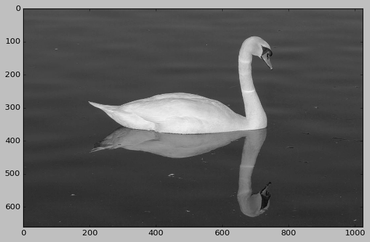

```
<PIL.Image.Image image mode=LA size=1024x660 at 0x120A53880>
```

```python
from six.moves import urllib
from PIL import Image
import matplotlib.pyplot as plt
import numpy as np

#################################################################################
# Seccion de codigo implementada para solucionar problemas con el certificado
import ssl

try:
    _create_unverified_https_context = ssl._create_unverified_context
except AttributeError:
    # Legacy Python that doesn't verify HTTPS certificates by default
    pass
else:
    # Handle target environment that doesn't support HTTPS verification
    ssl._create_default_https_context = _create_unverified_https_context

# Fin de la seccion de codigo auxiliar
#################################################################################


plt.style.use('classic')
img = Image.open(urllib.request.urlopen('https://biblioteca.acropolis.org/wp-content/uploads/2015/03/Cisne.jpg')).convert('LA')
#img = Image.open('lucy.jpg')
imggray = img.convert('LA')
imgmat = np.array(list(imggray.getdata(band=0)),float)

print(imgmat)

imgmat.shape = (imggray.size[1],imggray.size[0])

plt.figure(figsize=(9,6))
plt.imshow(imgmat,cmap='gray')
plt.show()
print(img)
```

```python
U,D,V = np.linalg.svd(imgmat)
imgmat.shape
```

```
(660, 1024)
```

```python
U.shape
```

```
(660, 660)
```

```python
V.shape
```

```
(1024, 1024)
```

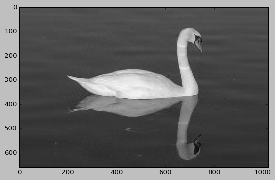

```
Felicidades la imagen está comprimida
```

```python
#Cuantos valores crees que son necesarios?
#A=U*D*V
#aqui los elegiremos---------------------------
# por las dimensiones de este caso en particular
#iremos de 0-660, siendo 660 como normalmente están los datos
#con 50 podemos observar que Lucy se ve casi igual, es decir conservamos aquello que en
# realidad estaba aportando a la imagen en este caso :D por medio de la variabilidad
#juega con el valor nvalue y ve que pasa con otros valores
nvalue = 50
#------------------------------
reconstimg = np.matrix(U[:,:nvalue])*np.diag(D[:nvalue])*np.matrix(V[:nvalue,:])
#ve las dimensiones de la imagen y su descomposicion
#660x1024= U(660X660)D(660X1024)V(1024x1024)
        #=U(660Xnvalues)D(nvaluesXnvalue)V(nvaluesx1024)

        #=U(660X50)(50X50)(50X1024)
plt.imshow(reconstimg,cmap='gray')
plt.show()
print("Felicidades la imagen está comprimida")
```

¡Ahora es tu turno!, comprime 3 imagenes

```
[153. 152. 158. ... 120. 120. 123.]
```

[figure not shown]

```
<PIL.Image.Image image mode=LA size=480x270 at 0x120A504F0>
```

[figure not shown]

```
imagen está comprimida
```

```python
#imagen 1
plt.style.use('classic')
img = Image.open(urllib.request.urlopen('http://dummy-images.com/animals/dummy-480x270-Impala.jpg')).convert('LA')
imggray = img.convert('LA')
imgmat = np.array(list(imggray.getdata(band=0)),float)

print(imgmat)

imgmat.shape = (imggray.size[1],imggray.size[0])

plt.figure(figsize=(9,6))
plt.imshow(imgmat,cmap='gray')
plt.show()
print(img)

# Compresión de imagen
U,D,V = np.linalg.svd(imgmat)
nvalue = 40

reconstimg = np.matrix(U[:,:nvalue])*np.diag(D[:nvalue])*np.matrix(V[:nvalue,:])
plt.imshow(reconstimg,cmap='gray')
plt.show()
print("imagen está comprimida")
```

```
[192. 195. 191. ...  53.  54.  55.]
```

[figure not shown]

```
<PIL.Image.Image image mode=LA size=600x900 at 0x1210E5F00>
```

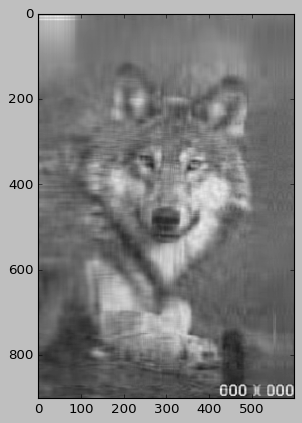

```
imagen está comprimida
```

```python
#imagen 2
plt.style.use('classic')
img = Image.open(urllib.request.urlopen('http://dummy-images.com/animals/dummy-600x900-CanisLupus.jpg')).convert('LA')
imggray = img.convert('LA')
imgmat = np.array(list(imggray.getdata(band=0)),float)

print(imgmat)

imgmat.shape = (imggray.size[1],imggray.size[0])

plt.figure(figsize=(9,6))
plt.imshow(imgmat,cmap='gray')
plt.show()
print(img)

# Compresión de imagen
U,D,V = np.linalg.svd(imgmat)
nvalue = 30

reconstimg = np.matrix(U[:,:nvalue])*np.diag(D[:nvalue])*np.matrix(V[:nvalue,:])
plt.imshow(reconstimg,cmap='gray')
plt.show()
print("imagen está comprimida")
```

```
[ 30.  25.  29. ... 147. 163. 165.]
```

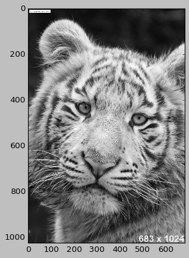

```
<PIL.Image.Image image mode=LA size=683x1024 at 0x120C88460>
```

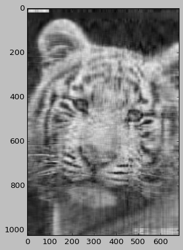

```
imagen está comprimida
```

```python
#imagen 3
plt.style.use('classic')
img = Image.open(urllib.request.urlopen('http://dummy-images.com/animals/dummy-683x1024-WhiteTiger.jpg')).convert('LA')
imggray = img.convert('LA')
imgmat = np.array(list(imggray.getdata(band=0)),float)

print(imgmat)

imgmat.shape = (imggray.size[1],imggray.size[0])

plt.figure(figsize=(9,6))
plt.imshow(imgmat,cmap='gray')
plt.show()
print(img)

# Compresión de imagen
U,D,V = np.linalg.svd(imgmat)
nvalue = 20

reconstimg = np.matrix(U[:,:nvalue])*np.diag(D[:nvalue])*np.matrix(V[:nvalue,:])
plt.imshow(reconstimg,cmap='gray')
plt.show()
print("imagen está comprimida")
```

# Ejercicio 3

**Feature importances**

Para este ejercicio, te pediremos que sigas el tutorial de la siguiente pagina:

https://towardsdatascience.com/pca-clearly-explained-how-when-why-to-use-it-and-feature-importance-a-guide-in-python-7c274582c37e

```python
import numpy as np
import matplotlib.pyplot as plt
from sklearn import datasets
from sklearn.decomposition import PCA
import pandas as pd
from sklearn.preprocessing import StandardScaler
plt.style.use('ggplot')
# Load the data
iris = datasets.load_iris()
X = iris.data
y = iris.target
# Z-score the features
scaler = StandardScaler()
scaler.fit(X)
X = scaler.transform(X)
# The PCA model
pca = PCA(n_components=2) # estimate only 2 PCs
X_new = pca.fit_transform(X) # project the original data into the PCA space
```

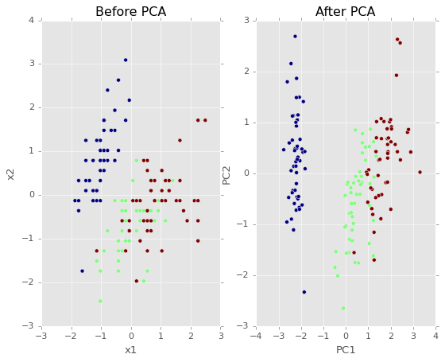

```python
fig, axes = plt.subplots(1,2)
axes[0].scatter(X[:,0], X[:,1], c=y)
axes[0].set_xlabel('x1')
axes[0].set_ylabel('x2')
axes[0].set_title('Before PCA')
axes[1].scatter(X_new[:,0], X_new[:,1], c=y)
axes[1].set_xlabel('PC1')
axes[1].set_ylabel('PC2')
axes[1].set_title('After PCA')
plt.show()
```

```python
print(pca.explained_variance_ratio_)
# array([0.72962445, 0.22850762])
```

```
[0.72962445 0.22850762]
```

### 6. Proof of eigenvalues of original covariance matrix being equal to the variances of the reduced space

```python
np.cov(X_new.T)
#array([[2.93808505e+00, 4.83198016e-16],
#       [4.83198016e-16, 9.20164904e-01]])

# La diagonal de los datos en la matriz de covarianza es igual a los valores actuales de la descomposicion eigenvalues de la covarianza guardados en "pca.explained_variance_:"
```

```
array([[2.93808505e+00, 5.33928780e-16],
       [5.33928780e-16, 9.20164904e-01]])
```

```python
# eigenvalues guardados en "pca.explained_variance_:"
pca.explained_variance_
```

```
array([2.93808505, 0.9201649 ])
```

### 7. Feature importance

```python
# La importancia de cada característica se refleja en la magnitud de los valores correspondientes en los vectores propios (mayor magnitud, mayor importancia).
# Estos son las caracteristicas mas importantes
print(abs( pca.components_ ))
#[[0.52106591 0.26934744 0.5804131 0.56485654]
# [0.37741762 0.92329566 0.02449161 0.06694199]]

# La primera fila en esta matriz es el PC1, el componente mas influyente
# podemos concluir que las características 1, 3 y 4 son las más importantes para PC1. De manera similar, podemos afirmar que la función 2 y luego la 1 son las más importantes para PC2.
```

```
[[0.52106591 0.26934744 0.5804131  0.56485654]
 [0.37741762 0.92329566 0.02449161 0.06694199]]
```

### 8. The biplot

El biplot es la mejor manera de visualizar todo en uno después de un análisis PCA.  
Hay una implementación en R pero no hay una implementación estándar en python, así que decidí escribir mi propia función para eso:

```python
def biplot(score, coeff , y):
    '''
    Author: Serafeim Loukas, serafeim.loukas@epfl.ch
    Inputs:
       score: the projected data
       coeff: the eigenvectors (PCs)
       y: the class labels
   '''
    xs = score[:,0] # projection on PC1
    ys = score[:,1] # projection on PC2
    n = coeff.shape[0] # number of variables
    plt.figure(figsize=(10,8), dpi=100)
    classes = np.unique(y)
    colors = ['g','r','y']
    markers=['o','^','x']
    for s,l in enumerate(classes):
        plt.scatter(xs[y==l],ys[y==l], c = colors[s], marker=markers[s]) # color based on group
    for i in range(n):
        #plot as arrows the variable scores (each variable has a score for PC1 and one for PC2)
        plt.arrow(0, 0, coeff[i,0], coeff[i,1], color = 'k', alpha = 0.9,linestyle = '-',linewidth = 1.5, overhang=0.2)
        plt.text(coeff[i,0]* 1.15, coeff[i,1] * 1.15, "Var"+str(i+1), color = 'k', ha = 'center', va = 'center',fontsize=10)

    plt.xlabel("PC{}".format(1), size=14)
    plt.ylabel("PC{}".format(2), size=14)
    limx= int(xs.max()) + 1
    limy= int(ys.max()) + 1
    plt.xlim([-limx,limx])
    plt.ylim([-limy,limy])
    plt.grid()
    plt.tick_params(axis='both', which='both', labelsize=14)
```

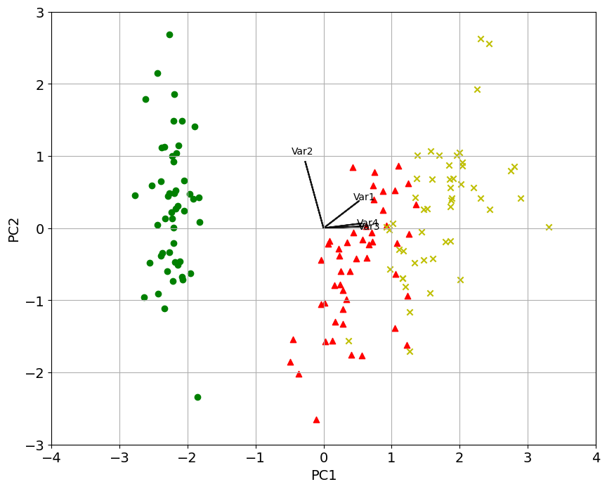

```python
# Llame a la función (asegúrese de ejecutar primero los bloques iniciales de código donde cargamos los datos del iris y realizamos el análisis PCA):
import matplotlib as mpl
mpl.rcParams.update(mpl.rcParamsDefault) # reset ggplot style
# Call the biplot function for only the first 2 PCs
biplot(X_new[:,0:2], np.transpose(pca.components_[0:2, :]), y)
plt.show()
```

```python
# Var 3 y Var 4 están extremadamente positivamente correlacionados
print(np.corrcoef(X[:,2], X[:,3])[1,0])
#0.9628654314027957
# Var 2and Var 3 are negatively correlated
print(np.corrcoef(X[:,1], X[:,2])[1,0])
#-0.42844010433054014
```

```
0.9628654314027957
-0.42844010433054014
```

Describe lo relevante del ejercicio y que descubriste de las variables análizadas.

De los mas relevante son los siguientes puntos:

# Preguntas finales

¿Qué es feature importance y para que nos sirve?

Aportan el peso que tiene cada componente a la varianza, entre mas absoluto sea el valor mayor es la importancia del feature o caracteristica, no todos los features de un componente tienen la misma importancia.

¿Qué hallazgos fueron los más relevantes durante el análisis del ejercicio?

Las relaciones entre variables y la comprencion de estas, debido que el ejercicio puede ser un poco complicado, pero separandolo en pasos e identificando las similitudes que existen entre la desvicion estandar, la varianza y covarianza entendí mejor la actvidad.

¿Dónde lo aplicarías o te sería de utilidad este conocimiento?

En conjuntos de datos con muchas caracteristicas o variables relacionadas, ya que nos permite averiguar relaciones entre ellas y los pesos o importancia de estas relaciones que son nombradas como componentes.